# Lab4

Luna Herschenfeld-Catalan

2024-02-05

## Lab 4: Fire and Tree Mortality

The database we’ll be working with today includes 36066 observations of individual trees involved in prescribed fires and wildfires occurring over 35 years, from 1981 to 2016. It is a subset of a larger fire and tree mortality database from the US Forest Service (see data description for the full database here: [link](https://www.nature.com/articles/s41597-020-0522-7#Sec10)). Our goal today is to predict the likelihood of tree mortality after a fire.

### Data Exploration

Outcome variable: *yr1status* = tree status (0=alive, 1=dead) assessed one year post-fire.

Predictors: *YrFireName, Species, Genus_species, DBH_cm, CVS_percent, BCHM_m, BTL* (Information on these variables available in the database metadata ([link](https://www.fs.usda.gov/rds/archive/products/RDS-2020-0001-2/_metadata_RDS-2020-0001-2.html))).

```r
trees_dat<- read_csv(file = "https://raw.githubusercontent.com/MaRo406/eds-232-machine-learning/main/data/trees-dat.csv")
```

### Data Splitting

> Question 1: Recode all the predictors to a zero_based integer form Question 2: Create trees_training (70%) and trees_test (30%) splits for the modeling

```r
set.seed(23)

# split the data into training and test sets
trees_split <- initial_split(trees_dat, prop = 0.7) # create training and test data
trees_train <- training(trees_split)
trees_test <- testing(trees_split)

trees_recipe <- recipe(yr1status ~ ., # have status as outcome variable
                      data = trees_train) %>%  # set recipe
  step_integer(all_string(), # make all character predictors into integers
               zero_based = T) %>%
  prep(trees_train)

trees_baked_train <- bake(trees_recipe,
                          new_data = trees_train)
```

> Question 3: How many observations are we using for training with this split?

The training data contains 25,246 observations.

```r
# check the number of observations
dim(trees_train)
```

```
## [1] 25246     9
```

### Simple Logistic Regression

Let’s start our modeling effort with some simple models: one predictor and one outcome each.

> Question 4: Choose the three predictors that most highly correlate with our outcome variable for further investigation.

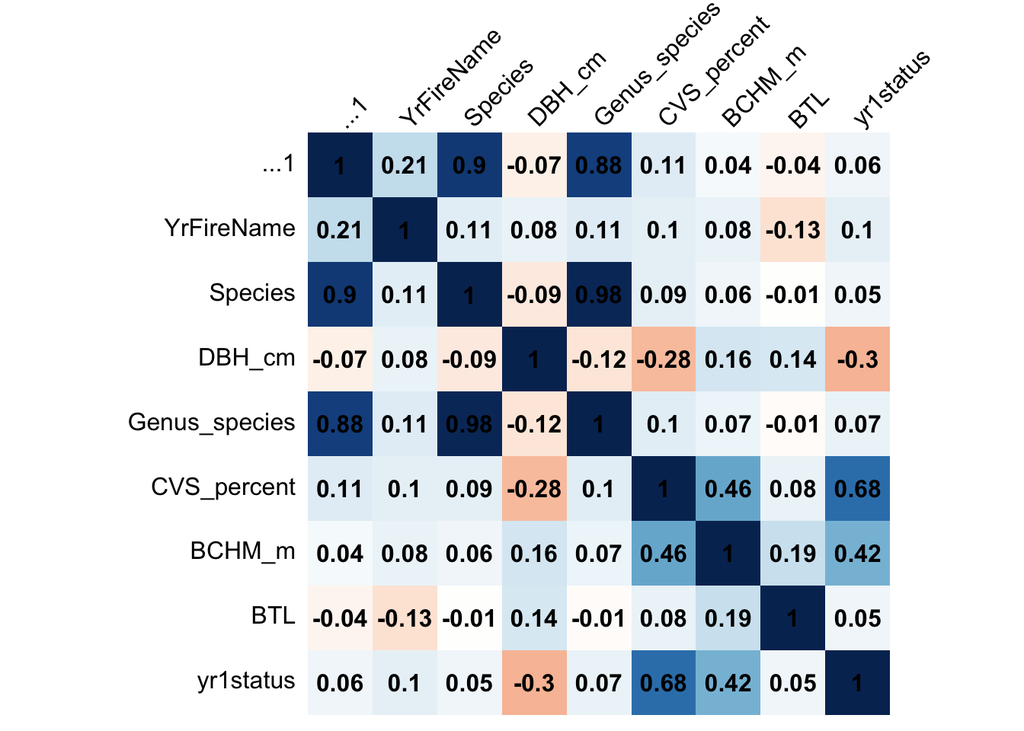

```r
# Obtain correlation matrix
corr_mat <- cor(trees_baked_train)

# Make a correlation plot between the variables
corrplot(corr_mat, method = "shade", shade.col = NA,
         tl.col = "black",
         tl.srt = 45,
         addCoef.col = "black",
         cl.pos = "n",
         order = "original")
```

Based on our correlation matrix, the variables that are most correlated with the `yr1status` are `CVS_percent`, `BCHM_m`, and `DBH_cm`.

> Question 5: Use glm() to fit three simple logistic regression models, one for each of the predictors you identified.

```r
mod1 <- glm(yr1status ~ CVS_percent, # formula with predicted ~ predictor
            data = trees_train, # use training data
            family = "binomial") # use binomial since the outcome is binary

mod2 <- glm(yr1status ~ BCHM_m,
            data = trees_train,
            family = "binomial")

mod3 <- glm(yr1status ~ DBH_cm,
            data = trees_train,
            family = "binomial")
```

### Interpret the Coefficients

We aren’t always interested in or able to interpret the model coefficients in a machine learning task. Often predictive accuracy is all we care about.

> Question 6: That said, take a stab at interpreting our model coefficients now.

```r
tab_model(mod1)
```

|  | yr 1 status |  |  |
| --- | --- | --- | --- |
| Predictors | Odds Ratios | CI | p |
| (Intercept) | 0.00 | 0.00 – 0.00 | **<0.001** |
| CVS percent | 1.08 | 1.08 – 1.08 | **<0.001** |
| Observations | 25246 |  |  |
| R<sup>2</sup> Tjur | 0.564 |  |  |

```r
tab_model(mod2)
```

|  | yr 1 status |  |  |
| --- | --- | --- | --- |
| Predictors | Odds Ratios | CI | p |
| (Intercept) | 0.15 | 0.15 – 0.16 | **<0.001** |
| BCHM m | 1.24 | 1.23 – 1.25 | **<0.001** |
| Observations | 25246 |  |  |
| R<sup>2</sup> Tjur | 0.182 |  |  |

```r
tab_model(mod3)
```

|  | yr 1 status |  |  |
| --- | --- | --- | --- |
| Predictors | Odds Ratios | CI | p |
| (Intercept) | 1.66 | 1.56 – 1.76 | **<0.001** |
| DBH cm | 0.94 | 0.94 – 0.95 | **<0.001** |
| Observations | 25246 |  |  |
| R<sup>2</sup> Tjur | 0.113 |  |  |

For the first model, the coefficient for CVS percent is 1.08, with a p-value of less than 0.001. This can be understood that we are over 99% confidence that for every 1 percent increase in crown volume scorched (CVS), the odds of the tree status 1 year post fire being dead increases by 1.08. For the second model, the coefficient for BCHM_m is 1.24, with a p-value of less than 0.001. This can be understood that we are over 99% confident that for every 1 meter vertical increase of maximum bark char height from the ground, the odds of the tree status 1 year post fire being dead increases by 1.24. For the third model, the coefficient for DBH_cm is 0.94, with a p-value of less than 0.001. This can be understood that we are over 99% confident that for every 1 centimeter increase of diameter, the odds of the tree status 1 year post fire being dead increases by 0.94. Since this is less than 1, the odds of being dead are decreasing as the diameter of the tree increases.

> Question 7: Now let’s visualize the results from these models. Plot the fit to the training data of each model.

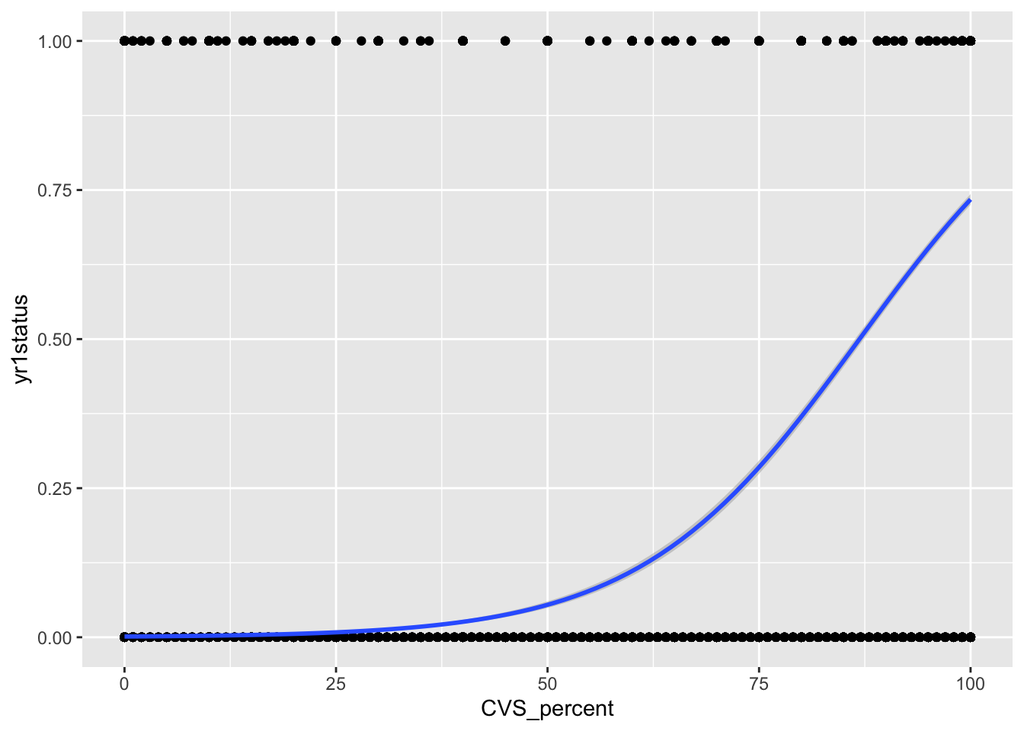

```r
ggplot(trees_baked_train, aes(x = CVS_percent, y = yr1status)) +
  geom_point() +
  stat_smooth(method = "glm",
              se = T,
              method.args = list(family = "binomial"))
```

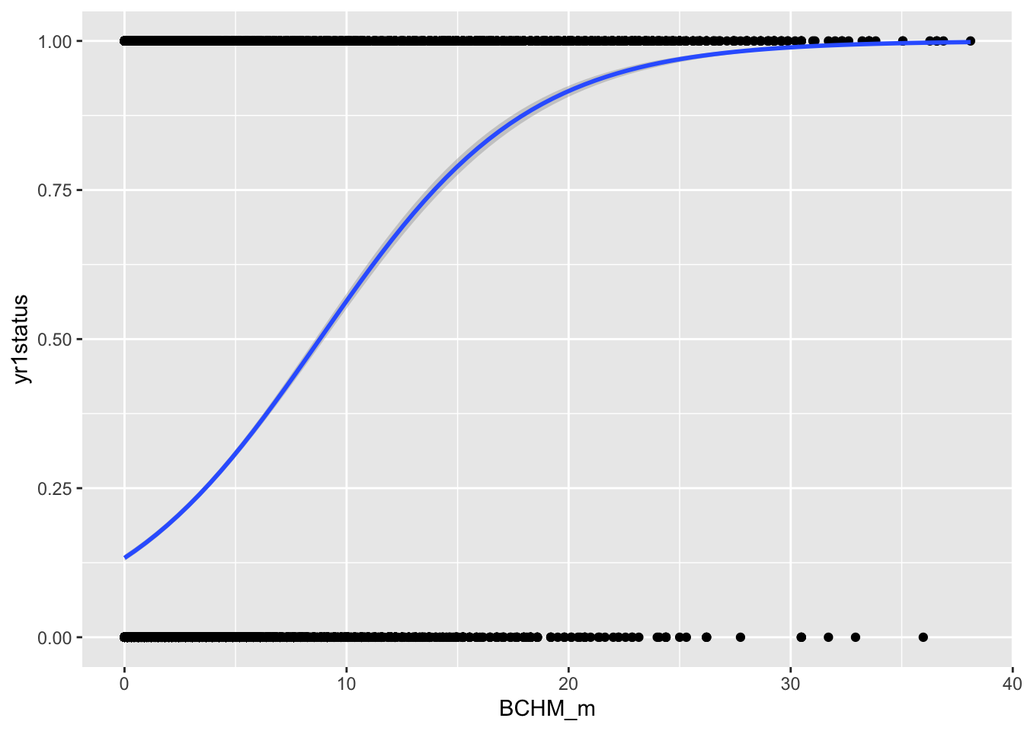

```r
ggplot(trees_baked_train, aes(x = BCHM_m, y = yr1status)) +
  geom_point() +
  stat_smooth(method = "glm",
              se = T,
              method.args = list(family = "binomial"))
```

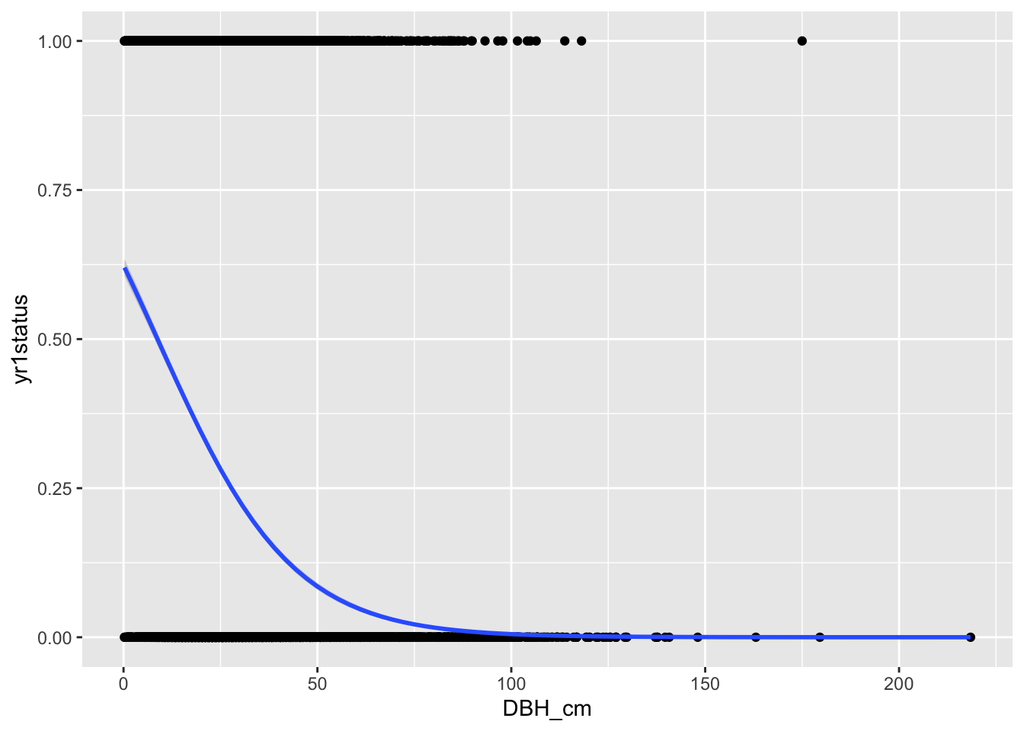

```r
ggplot(trees_baked_train, aes(x = DBH_cm, y = yr1status)) +
  geom_point() +
  stat_smooth(method = "glm",
              se = T,
              method.args = list(family = "binomial"))
```

### Multiple Logistic Regression

Let’s not limit ourselves to a single-predictor model. More predictors might lead to better model performance.

> Question 8: Use glm() to fit a multiple logistic regression called “logistic_full”, with all three of the predictors included. Which of these are significant in the resulting model?

All three of these variables are significant in the resulting model. The p-values for each variable are significant well above a 95% confidence level.

```r
logistic_full <- glm(yr1status ~ CVS_percent + BCHM_m + DBH_cm,
                     data = trees_train,
                     family = "binomial")

broom::tidy(logistic_full)
```

```
## # A tibble: 4 × 5
##   term        estimate std.error statistic   p.value
##   <chr>          <dbl>     <dbl>     <dbl>     <dbl>
## 1 (Intercept)  -4.98     0.118       -42.2 0
## 2 CVS_percent   0.0630   0.00121      52.2 0
## 3 BCHM_m        0.157    0.00538      29.2 7.71e-188
## 4 DBH_cm       -0.0567   0.00190     -29.8 2.10e-195
```

### Estimate Model Accuracy

Now we want to estimate our model’s generalizability using resampling.

> Question 9: Use cross validation to assess model accuracy. Use caret::train() to fit four 10-fold cross-validated models (cv_model1, cv_model2, cv_model3, cv_model4) that correspond to each of the four models we’ve fit so far: three simple logistic regression models corresponding to each of the three key predictors (CVS_percent, DBH_cm, BCHM_m) and a multiple logistic regression model that combines all three predictors.

```r
# make the yr1status column into a factor
trees_train$yr1status <- as.factor(trees_train$yr1status)

# create subsets for cross validation
ctrl <- trainControl(method = "cv", # set method as cross validation
                     number = 10) # default number of k-folds

set.seed(123)
cv_model1 <- caret::train(yr1status ~ CVS_percent,
                          data = trees_train,
                          method = "glm",
                          family = "binomial",
                          trControl = ctrl)
set.seed(123)
cv_model2 <- caret::train(yr1status ~ BCHM_m,
                          data = trees_train,
                          method = "glm",
                          family = "binomial",
                          trControl = ctrl)
set.seed(123)
cv_model3 <- caret::train(yr1status ~ DBH_cm,
                          data = trees_train,
                          method = "glm",
                          family = "binomial",
                          trControl = ctrl)
set.seed(123)
cv_model4 <- caret::train(yr1status ~ CVS_percent + BCHM_m + DBH_cm,
                          data = trees_train,
                          method = "glm",
                          family = "binomial",
                          trControl = ctrl)
```

> Question 10: Use caret::resamples() to extract then compare the classification accuracy for each model. (Hint: resamples() wont give you what you need unless you convert the outcome variable to factor form). Which model has the highest accuracy?

The mean accuracy for each model is 0.896 for the first model (CVS_percent), 0.7722 for the second model (BCHM_m), 0.7488 for the third model (DBH_cm), and 0.9026 for the 4th model that used all 3 variables as predictors. Therefore, the model with the highest accuracy was Model 4, the multiple logistic regression model with an average accuracy of 90%.

```r
# extract sample performance
summary(caret::resamples(

  list(
    # model on the left is the one WE made
    cv_model1 = cv_model1,
    cv_model2 = cv_model2,
    cv_model3 = cv_model3,
    cv_model4 = cv_model4
  ))
  )$statistic$Accuracy
```

```
##                Min.   1st Qu.    Median      Mean   3rd Qu.      Max. NA's
## cv_model1 0.8902970 0.8934335 0.8966336 0.8964192 0.8997030 0.9017433    0
## cv_model2 0.7627723 0.7673037 0.7700994 0.7722411 0.7769414 0.7865347    0
## cv_model3 0.7424723 0.7470048 0.7491089 0.7488704 0.7507181 0.7577197    0
## cv_model4 0.8950495 0.8984746 0.9033471 0.9026374 0.9058322 0.9104950    0
```

Let’s move forward with this single most accurate model.

> Question 11: Compute the confusion matrix and overall fraction of correct predictions by the model.

```r
# use the model to predict values based on training data
predicted <- predict(cv_model4, # model specified
                     trees_train)

# create confusion matrix
results <- confusionMatrix(data = predicted,
                reference = trees_train$yr1status)

results
```

```
## Confusion Matrix and Statistics
##
##           Reference
## Prediction     0     1
##          0 16466   835
##          1  1619  6326
##
##                Accuracy : 0.9028
##                  95% CI : (0.8991, 0.9064)
##     No Information Rate : 0.7164
##     P-Value [Acc > NIR] : < 2.2e-16
##
##                   Kappa : 0.7685
##
##  Mcnemar's Test P-Value : < 2.2e-16
##
##             Sensitivity : 0.9105
##             Specificity : 0.8834
##          Pos Pred Value : 0.9517
##          Neg Pred Value : 0.7962
##              Prevalence : 0.7164
##          Detection Rate : 0.6522
##    Detection Prevalence : 0.6853
##       Balanced Accuracy : 0.8969
##
##        'Positive' Class : 0
##
```

> Question 12: Explain what the confusion matrix is telling you about the types of mistakes made by logistic regression.

The confusion matrix is telling us about the number of true negatives/positives and false negative/positives. The mistakes made by the logistic regression are when the model predicts that a tree is dead, but in the real data set it is alive (P:1, A:0; that is a false positive), or the model predicts that a tree is alive, but in the real data set it is dead (P:0, A:1; that is a false negative).

> Question 13: What is the overall accuracy of the model? How is this calculated?

The overall accuracy of the model is (16466 + 6326) / (1619 + 6326 + 16466 + 835), which is the number of true neg + true pos divided by the total number of observations. This equals 0.9028, which is equal to an accuracy of 90.28%.

### Test Final Model

Alright, now we’ll take our most accurate model and make predictions on some unseen data (the test data).

> Question 14: Now that we have identified our best model, evaluate it by running a prediction on the test data, trees_test.

```r
# fore generating test metrics
# predicted_test <- predict(cv_model4, trees_test) %>%
#   bind_cols(trees_test) %>%
#   rename("pred" = "...1") %>%
#   mutate(pred = as.numeric(pred))
#
# test_metrics <- predicted_test %>%
#   metrics(yr1status, pred)
#
# test_metrics

# for generating confusion matrix
predicted_test_df <- predict(cv_model4, trees_test)

# create confusion matrix
confusionMatrix(data = predicted_test_df,
                reference = as.factor(trees_test$yr1status))
```

```
## Confusion Matrix and Statistics
##
##           Reference
## Prediction    0    1
##          0 7083  338
##          1  665 2734
##
##                Accuracy : 0.9073
##                  95% CI : (0.9017, 0.9127)
##     No Information Rate : 0.7161
##     P-Value [Acc > NIR] : < 2.2e-16
##
##                   Kappa : 0.7791
##
##  Mcnemar's Test P-Value : < 2.2e-16
##
##             Sensitivity : 0.9142
##             Specificity : 0.8900
##          Pos Pred Value : 0.9545
##          Neg Pred Value : 0.8044
##              Prevalence : 0.7161
##          Detection Rate : 0.6546
##    Detection Prevalence : 0.6859
##       Balanced Accuracy : 0.9021
##
##        'Positive' Class : 0
##
```

> Question 15: How does the accuracy of this final model on the test data compare to its cross validation accuracy? Do you find this to be surprising? Why or why not?

The accuracy of this model on the test data is 0.9073, which makes it 90.73% accuracy. This is surprising because it is performing equal, if not a fraction of a percent better on the test data than on the training data (90.28%) . I would expect it to perform a little worse since it on unseen data. However, the idea of using training and test data is that the training data is an accurate representation of the entire data set, so we hope that the model we created on the training data is able to predict with equal accuracy on the test data.